# Data Validation Report: pH Sensor Evaluation

**Evaluator:** Beckett Colson, MIT/WHOI PhD Student - Engineering Background

OOI Early Career Data Workshop in Chemistry July 30 - August 3, 2018 Rutgers University

### Document Context and Scope:

Workshop discussions and presentations indicated that the data from the pH sensors installed on the OOI data arrays are not yet of the quality desired. The [OOI pH Sensor Data Product Specifications](https://oceanobservatories.org/wp-content/uploads/2015/10/1341-00510_Data_Product_Spec_PHWATER_OOI.pdf) specify that the level 2 science program requirement is an accuracy of +/- 0.01, precision of +/- 0.005, and drift of not more than 0.01 pH units.

This report, rather than focus on this observation, makes an attempt at illuminating the symptoms hidden in the raw data products. For example, a decreasing reference signal over time could indicate biofouling of the instrument, and would show up in the calculated pH data as an increase in noise. This report covers an non-exhaustive list of symptoms, potential causes, and potential solutions. By understanding the symptoms affecting the quality of the data, the hope is that adjustments can be made to improve the performance of these instruments. Tests for these "symptoms" could be used in quality checking of other data sets not considered in this report.

Two sites are considered, one cabled and one not, in order to cover a range of observed data issues, both from the sensor performance perspective as well as from the data presentation and handling perspective. This report also attempts to identify the symptoms of two known issues mentioned in the workshop by looking at the raw data received from the instrument.

**The known issues mentioned during the workshop include:**

**Deployment Problems:** The pump installed on the instrument is not always able to clear air bubbles trapped in the system, which causes a failure of the instrument. The deployment procedure has been adjusted to avoid this issue by ensuring the instrument is not turned on until after it is in the water.

**Biofouling:** Instrument variability increases over time throughout deployments

## 0. Selected Data In Report

The following instruments were selected for this report

| Deployment Location | Instrument | Reference Designator | Method | Stream | Start Date | End Date |
| --- | --- | --- | --- | --- | --- | --- |
| Coastal Endurance, Oregon Shelf Cabled Benthic Experiment Package | pH | [CE02SHBP-LJ01D-10-PHSEND103](https://ooinet.oceanobservatories.org/data_access/?search=CE02SHBP-LJ01D-10-PHSEND103#CE02SHBP-LJ01D-10-PHSEND103/phsen_data_record) | streamed | phsen_data_record | 2018-06-01 | 2018-08-01 |
| Coastal Pioneer, Inshore Surface Mooring | pH | [CP03ISSM-MFD35-06-PHSEND000](https://ooinet.oceanobservatories.org/data_access/?search=CP03ISSM-MFD35-06-PHSEND000#CP03ISSM-MFD35-06-PHSEND000/phsen_abcdef_instrument) | recovered_inst | phsen_abcdef_instrument | 2017-03-15 | 2018-03-15 |

# 1. Metadata Checks

This section will query the server for the metadata (Vocabulary, Deployment, Calibration, and Annotations), and check that it is present and correct.

First, a few setup tasks:

```python
# Import Python Libraries used throughout report
import datetime
import time
import requests
import re
import os
import pandas as pd
import xarray as xr
import numpy as np
import matplotlib.pyplot as plt
import seaborn as sns # package for nice plotting defaults
sns.set()
```

```python
# Setup Parameters to Load the Data

# Data Set 1 Parameters:
site_1 = 'CE02SHBP'
node_1 = 'LJ01D'
instrument_1 = '10-PHSEND103'
method_1 = 'streamed'
stream_1 = 'phsen_data_record'
beginDate_1 = '2018-06-01T00:00:00.000Z'
endDate_1 = '2018-08-01T00:00:00.000Z'

# Data Set 2 Parameters:
site_2 = 'CP03ISSM'
node_2 = 'MFD35'
instrument_2 = '06-PHSEND000'
method_2 = 'recovered_inst' # This will be the full recovered data set from the instrument's internal logger - it is not decimated like the telemetered data
stream_2 = 'phsen_abcdef_instrument' #It's named something different because this is recovered data so the labels are inconsistent
beginDate_2 = '2017-03-15T00:00:00.000Z'
endDate_2 = '2018-03-15T00:00:00.000Z'
```

```python
print('Reference Designator 1: '+site_1+'-'+node_1+'-'+instrument_1)
print('Reference Designator 2: '+site_2+'-'+node_2+'-'+instrument_2)
# these are handy for searching the online data portal and for requesting data
```

```
Reference Designator 1: CE02SHBP-LJ01D-10-PHSEND103
Reference Designator 2: CP03ISSM-MFD35-06-PHSEND000
```

*Usability comment:* The inconsistent naming of variables, i.e. 'phsen_data_record' vs 'phsen_abcdef_instrument' makes it challenging to compare data from different sites. Thankfully this is not insurmountable!

**Username and token note:** This information is personal to your account. I've removed it in the final report.

To obtain your personal username and token for the API, go to https://ooinet.oceanobservatories.org/ sign up for an account, and navigate to your user profile.

```python
# Set Username and Token - This information is personal to your account
USERNAME = ''
TOKEN =  ''
```

### 1. a. Check Vocabulary Metadata

```python
# Pull the Vocabulary record for data set 1

VOCAB_BASE_URL = 'https://ooinet.oceanobservatories.org/api/m2m/12586/vocab/inv'
request_url ='/'.join((VOCAB_BASE_URL,site_1,node_1,instrument_1))

# Retrieve vocabulary information for a given instrument
r = requests.get(request_url, auth=(USERNAME, TOKEN))
data = r.json()

print('Data Set 2 Vocabulary Data')
data # prints the data so we can see it
```

```
Data Set 2 Vocabulary Data
```

```
[{'@class': '.VocabRecord',
  'model': 'SAMI-pH',
  'manufacturer': 'Sunburst',
  'vocabId': 56,
  'refdes': 'CE02SHBP-LJ01D-10-PHSEND103',
  'instrument': 'Seawater pH',
  'tocL1': 'Coastal Endurance',
  'tocL2': 'Oregon Shelf Cabled Benthic Experiment Package',
  'tocL3': 'Low-Power JBox (LJ01D)',
  'mindepth': 80.0,
  'maxdepth': 80.0}]
```

```python
# let's rewrite that in a more user friendly way
print('Data Set 1 Details')
print(', '.join((data[0]['tocL1'],data[0]['tocL2'],data[0]['instrument'],str(data[0]['mindepth'])+' m')))
print(beginDate_1)
print(endDate_1)
```

```
Data Set 1 Details
Coastal Endurance, Oregon Shelf Cabled Benthic Experiment Package, Seawater pH, 80.0 m
2018-06-01T00:00:00.000Z
2018-08-01T00:00:00.000Z
```

Looks good!

```python
# Pull the Vocabulary record for data set 2

VOCAB_BASE_URL = 'https://ooinet.oceanobservatories.org/api/m2m/12586/vocab/inv'
request_url ='/'.join((VOCAB_BASE_URL,site_2,node_2,instrument_2))

# Retrieve vocabulary information for a given instrument
r = requests.get(request_url, auth=(USERNAME, TOKEN))
data = r.json()

print('Data Set 2 Vocabulary Data')
data # prints the data so we can see it
```

```
Data Set 2 Vocabulary Data
```

```
[{'@class': '.VocabRecord',
  'model': 'SAMI-pH',
  'manufacturer': 'Sunburst',
  'vocabId': 559,
  'refdes': 'CP03ISSM-MFD35-06-PHSEND000',
  'instrument': 'Seawater pH',
  'tocL1': 'Coastal Pioneer',
  'tocL2': 'Inshore Surface Mooring',
  'tocL3': 'Seafloor Multi-Function Node (MFN)',
  'mindepth': 91.5,
  'maxdepth': 91.5}]
```

```python
# let's rewrite that in a more user friendly way
print('Data Set 2 Details')
print(', '.join((data[0]['tocL1'],data[0]['tocL2'],data[0]['instrument'],str(data[0]['mindepth'])+' m')))
print(beginDate_2)
print(endDate_2)
```

```
Data Set 2 Details
Coastal Pioneer, Inshore Surface Mooring, Seawater pH, 91.5 m
2017-03-15T00:00:00.000Z
2018-03-15T00:00:00.000Z
```

Looks good!

### 1. b. Check Deployment Metadata

```python
# Specify some functions to convert timestamps
ntp_epoch = datetime.datetime(1900, 1, 1)
unix_epoch = datetime.datetime(1970, 1, 1)
ntp_delta = (unix_epoch - ntp_epoch).total_seconds()

def ntp_seconds_to_datetime(ntp_seconds):
    return datetime.datetime.utcfromtimestamp(ntp_seconds - ntp_delta).replace(microsecond=0)

def convert_time(ms):
  if ms != None:
    return datetime.datetime.utcfromtimestamp(ms/1000)
  else:
    return None
```

```python
# Setup the API request url for data set 1 and show results
ASSET_API = 'https://ooinet.oceanobservatories.org/api/m2m/12587'
data_request_url = ASSET_API + '/events/deployment/query'
params = {
  'beginDT':beginDate_1,
  'endDT':endDate_1,
  'refdes':site_1+'-'+node_1+'-'+instrument_1,
}

# Grab the information from the server
r = requests.get(data_request_url, params=params, auth=(USERNAME, TOKEN))
data = r.json()

df = pd.DataFrame() # Setup empty array
for d in data:
  df = df.append({
      'deployment': d['deploymentNumber'],
      'start': convert_time(d['eventStartTime']),
      'stop': convert_time(d['eventStopTime']),
      'latitude': d['location']['latitude'],
      'longitude': d['location']['longitude'],
      'sensor': d['sensor']['uid'],
      'asset_id': d['sensor']['assetId'],
    }, ignore_index=True)
df
```

|  | asset_id | deployment | latitude | longitude | sensor | start | stop |
| --- | --- | --- | --- | --- | --- | --- | --- |
| 0 | 581.0 | 4.0 | 44.63708 | -124.30595 | ATOSU-70571-00004 | 2017-09-10 14:30:00 | 2018-06-29 02:30:00 |
| 1 | 579.0 | 5.0 | 44.63708 | -124.30595 | ATOSU-70571-00002 | 2018-06-30 02:30:00 | None |

Great. Looks like 2 different sensors were deployed over this time period for deployments 4 and 5 at this location. Checking the lat-long, it seems right.

```python
# Setup the API request url for data set 2 and output the results
data_request_url = ASSET_API + '/events/deployment/query'
params = {
  'beginDT':beginDate_2,
  'endDT':endDate_2,
  'refdes':site_2+'-'+node_2+'-'+instrument_2,
}

# Grab the information from the server
r = requests.get(data_request_url, params=params, auth=(USERNAME, TOKEN))
data = r.json()

df = pd.DataFrame() # Setup empty array
for d in data:
  df = df.append({
      'deployment': d['deploymentNumber'],
      'start': convert_time(d['eventStartTime']),
      'stop': convert_time(d['eventStopTime']),
      'latitude': d['location']['latitude'],
      'longitude': d['location']['longitude'],
      'sensor': d['sensor']['uid'],
      'asset_id': d['sensor']['assetId'],
    }, ignore_index=True)
df
```

|  | asset_id | deployment | latitude | longitude | sensor | start | stop |
| --- | --- | --- | --- | --- | --- | --- | --- |
| 0 | 1361.0 | 5.0 | 40.361920 | -70.878270 | CGINS-PHSEND-P0157 | 2016-10-11 13:39:00 | 2017-06-15 15:56:00 |
| 1 | 221.0 | 6.0 | 40.367067 | -70.881617 | CGINS-PHSEND-P0096 | 2017-06-15 13:43:00 | 2017-11-01 14:17:00 |
| 2 | 1359.0 | 7.0 | 40.358983 | -70.885467 | CGINS-PHSEND-P0158 | 2017-11-01 12:22:00 | 2018-03-28 16:56:00 |

Great. Looks like 3 different sensors were deployed over this time period for deployments 5, 6, and 7 at this location. Checking the lat-long, it seems right.

*Note:* It is unclear whether or not the sensor name here (CGINS-PHSEND-P####) vs at the other site (ATOSU-70571-#####) indicates a different type of sensor, like a different model of the Sunburst SAMI-pH sensor, or if it is an artifact of the fact these are on two different arrays. For future data quality evaulation, it would be good to clarify whether these are indeed different models.

### 1. c. Check Calibration Metadata

```python
# Check calibration data for data set 1
# Setup the API request url for data set 1
data_request_url = ASSET_API + '/asset/cal'
params = {
  'beginDT':beginDate_1,
  'endDT':endDate_1,
  'refdes':site_1+'-'+node_1+'-'+instrument_1,
}

# Grab the information from the server
r = requests.get(data_request_url, params=params, auth=(USERNAME, TOKEN))
data = r.json()

# Reformat the data into a pretty table
df = pd.DataFrame() # Setup empty array
for d in data:
  for dd in d['sensor']['calibration']:
    for ddd in dd['calData']:
      df = df.append({
        'value': ddd['value'],
        'start': convert_time(ddd['eventStartTime']),
        'stop': convert_time(ddd['eventStopTime']),
        'name': ddd['eventName'],
        'assetUid': ddd['assetUid'],
        }, ignore_index=True)

df = df.sort_values(by=['start','name'])
df
```

|  | assetUid | name | start | stop | value |
| --- | --- | --- | --- | --- | --- |
| 1 | ATOSU-70571-00002 | CC_ea434 | 2017-12-11 | None | 17372.0 |
| 2 | ATOSU-70571-00002 | CC_ea578 | 2017-12-11 | None | 94.1 |
| 6 | ATOSU-70571-00002 | CC_eb434 | 2017-12-11 | None | 2284.1 |
| 0 | ATOSU-70571-00002 | CC_eb578 | 2017-12-11 | None | 38676.5 |
| 3 | ATOSU-70571-00002 | CC_ind_off | 2017-12-11 | None | 0.0 |
| 5 | ATOSU-70571-00002 | CC_ind_slp | 2017-12-11 | None | 1.0 |
| 4 | ATOSU-70571-00002 | CC_psal | 2017-12-11 | None | 35.0 |

Looks like we only have calibration information for the second deployment of data set 1. The calibration information appears to be **missing** for deployment 4 at reference designator: CE02SHBP-LJ01D-10-PHSEND103. We will see later that there are problems with that deployment, and unfortunately it appears that there was a problem with the sensor (not just that the calibration info is unavailable)

It is also worth noting here that the sensor used in deployment 5 was calibrated 2017-12-11 and deployed 2018-06-30. It is unclear from the documentation whether or not an ~ 6 month wait (while presumably sitting in storage somewhere) is acceptable for this instrument or not. In the next set of data (as we will see), the calibration data corresponds with the date of deployment. This suggests that the calibration process is relatively simple *or* that the date data for the calibration corresponds to the date it was entered into the system and not necessarily the date the instrument was calibrated. If it is simple, a suggestion moving forward would be to calibrate the instrument right before deployment.

Let's look at the calibration info for data set 2

```python
# Check calibration data for data set 2
# Setup the API request url
data_request_url = ASSET_API + '/asset/cal'
params = {
  'beginDT':beginDate_2,
  'endDT':endDate_2,
  'refdes':site_2+'-'+node_2+'-'+instrument_2,
}

# Grab the information from the server
r = requests.get(data_request_url, params=params, auth=(USERNAME, TOKEN))
data = r.json()

# Reformat the data into a pretty table
df = pd.DataFrame() # Setup empty array
for d in data:
  for dd in d['sensor']['calibration']:
    for ddd in dd['calData']:
      df = df.append({
        'value': ddd['value'],
        'start': convert_time(ddd['eventStartTime']),
        'stop': convert_time(ddd['eventStopTime']),
        'name': ddd['eventName'],
        'assetUid': ddd['assetUid'],
        }, ignore_index=True)

df = df.sort_values(by=['start','name'])
df
```

|  | assetUid | name | start | stop | value |
| --- | --- | --- | --- | --- | --- |
| 2 | CGINS-PHSEND-P0157 | CC_ea434 | 2016-10-11 | None | 17372.0 |
| 5 | CGINS-PHSEND-P0157 | CC_ea578 | 2016-10-11 | None | 94.1 |
| 12 | CGINS-PHSEND-P0157 | CC_eb434 | 2016-10-11 | None | 2284.1 |
| 1 | CGINS-PHSEND-P0157 | CC_eb578 | 2016-10-11 | None | 38676.5 |
| 7 | CGINS-PHSEND-P0157 | CC_ind_off | 2016-10-11 | None | 0.0 |
| 10 | CGINS-PHSEND-P0157 | CC_ind_slp | 2016-10-11 | None | 1.0 |
| 8 | CGINS-PHSEND-P0157 | CC_psal | 2016-10-11 | None | 35.0 |
| 30 | CGINS-PHSEND-P0158 | CC_ea434 | 2016-10-12 | None | 17372.0 |
| 33 | CGINS-PHSEND-P0158 | CC_ea578 | 2016-10-12 | None | 94.1 |
| 41 | CGINS-PHSEND-P0158 | CC_eb434 | 2016-10-12 | None | 2284.1 |
| 29 | CGINS-PHSEND-P0158 | CC_eb578 | 2016-10-12 | None | 38676.5 |
| 35 | CGINS-PHSEND-P0158 | CC_ind_off | 2016-10-12 | None | 0.0 |
| 39 | CGINS-PHSEND-P0158 | CC_ind_slp | 2016-10-12 | None | 1.0 |
| 37 | CGINS-PHSEND-P0158 | CC_psal | 2016-10-12 | None | 35.0 |
| 17 | CGINS-PHSEND-P0096 | CC_ea434 | 2017-01-05 | None | 17372.0 |
| 19 | CGINS-PHSEND-P0096 | CC_ea578 | 2017-01-05 | None | 94.1 |
| 27 | CGINS-PHSEND-P0096 | CC_eb434 | 2017-01-05 | None | 2284.1 |
| 15 | CGINS-PHSEND-P0096 | CC_eb578 | 2017-01-05 | None | 38676.5 |
| 20 | CGINS-PHSEND-P0096 | CC_ind_off | 2017-01-05 | None | 0.0 |
| 25 | CGINS-PHSEND-P0096 | CC_ind_slp | 2017-01-05 | None | 1.0 |
| 23 | CGINS-PHSEND-P0096 | CC_psal | 2017-01-05 | None | 35.0 |
| 31 | CGINS-PHSEND-P0158 | CC_ea434 | 2017-07-26 | None | 17372.0 |
| 32 | CGINS-PHSEND-P0158 | CC_ea578 | 2017-07-26 | None | 94.1 |
| 40 | CGINS-PHSEND-P0158 | CC_eb434 | 2017-07-26 | None | 2284.1 |
| 28 | CGINS-PHSEND-P0158 | CC_eb578 | 2017-07-26 | None | 38676.5 |
| 34 | CGINS-PHSEND-P0158 | CC_ind_off | 2017-07-26 | None | 0.0 |
| 38 | CGINS-PHSEND-P0158 | CC_ind_slp | 2017-07-26 | None | 1.0 |
| 36 | CGINS-PHSEND-P0158 | CC_psal | 2017-07-26 | None | 35.0 |
| 3 | CGINS-PHSEND-P0157 | CC_ea434 | 2017-07-27 | None | 17372.0 |
| 4 | CGINS-PHSEND-P0157 | CC_ea578 | 2017-07-27 | None | 94.1 |
| 13 | CGINS-PHSEND-P0157 | CC_eb434 | 2017-07-27 | None | 2284.1 |
| 0 | CGINS-PHSEND-P0157 | CC_eb578 | 2017-07-27 | None | 38676.5 |
| 6 | CGINS-PHSEND-P0157 | CC_ind_off | 2017-07-27 | None | 0.0 |
| 11 | CGINS-PHSEND-P0157 | CC_ind_slp | 2017-07-27 | None | 1.0 |
| 9 | CGINS-PHSEND-P0157 | CC_psal | 2017-07-27 | None | 35.0 |
| 16 | CGINS-PHSEND-P0096 | CC_ea434 | 2018-01-12 | None | 17372.0 |
| 18 | CGINS-PHSEND-P0096 | CC_ea578 | 2018-01-12 | None | 94.1 |
| 26 | CGINS-PHSEND-P0096 | CC_eb434 | 2018-01-12 | None | 2284.1 |
| 14 | CGINS-PHSEND-P0096 | CC_eb578 | 2018-01-12 | None | 38676.5 |
| 21 | CGINS-PHSEND-P0096 | CC_ind_off | 2018-01-12 | None | 0.0 |
| 24 | CGINS-PHSEND-P0096 | CC_ind_slp | 2018-01-12 | None | 1.0 |
| 22 | CGINS-PHSEND-P0096 | CC_psal | 2018-01-12 | None | 35.0 |

There's a lot more information here! Let's go through the instruments one by one.

CGINS-PHSEND-P0157 was deployed 2016-10-11 until 2017-06-15 (according to our deployment metadata). We have calibration data for 2017-07-27 (a bit more than a month after the deployment) and 2016-10-11 (the day of the deployment). It is unclear whether the calibration data after the deployment is after the instrument has been refurbished/reset by the vendor. If it is, it isn't appropriate to pull that data with this data request, because it would be misleading.

CGINS-PHSEND-P0096 was deployed 2017-06-15 until 2017-11-01 (according to our deployment metadata). We have calibration data for 2017-01-05 (~ 5 months before deployment) and 2018-01-12 (after deployment). Again it isn't clear if this is after the instrument has been refurbished by the vendor, additonally it isn't clear if an extended wait period between calibration and deployment is an issue or not.

CGINS-PHSEND-P00158 was deployed 2017-11-01 until 2018-03-28 (according to our deployment metadata). We have calibration data for 2016-10-12 and 2017-07-26, both before the deployment.

It is also worth noting that the calibration information for all of these is the **exactly** the same. That seems *very suspicious*, but could be correct. The calibration documents (which I was unable to locate) would be needed to verify this.

I attempted to find the documentation about the calibration parameters. The [pH sensor Data Product Specification (DPS)](https://oceanobservatories.org/wp-content/uploads/2015/10/1341-00510_Data_Product_Spec_PHWATER_OOI.pdf) specifies to look for the "PHSEN Processing Flow document (DCN 1342-00510)" I was unable to find this document. However, as we learned in the workshop, the OOI uses [Alfresco](https://alfresco.oceanobservatories.org/alfresco/faces/jsp/browse/browse.jsp) for document storage. Looking at the "Instrument & Platform Documents" folder, we have calibration and repair documents and test documents. There is **nothing** in the cabled array folder for either of these. Perhaps the information is located elsewhere. For the coastal-global array we can access calibration documents and test documents. I was unable to match any of the information to the specific sensors evaluated in this report. *A clearer and unilaterally used instrument serial # or identification code is needed!* There's a lot of useful data quality evaluation information in these documents, such as shipping and repair information, calibration information, etc. Looking at the calibration documents we can find out a bit more about the calibration process, but reverse engineering what the different variables mean is outside the scope of this report.

### 1. d. Check Annotation Metadata

```python
# Request annotations for data set 1
ANNO_API = 'https://ooinet.oceanobservatories.org/api/m2m/12580/anno/find'
params = {
  'beginDT':int(datetime.date(2018,6,1).strftime('%s'))*1000,
  'endDT':int(datetime.date(2018,8,1).strftime('%s'))*1000,
  'refdes':site_1+'-'+node_1+'-'+instrument_1,
}


r = requests.get(ANNO_API, params=params, auth=(USERNAME, TOKEN))
data = r.json()

df = pd.DataFrame() # Setup empty array
for d in data:
  df = df.append({
    'annotation': d['annotation'],
    'start': convert_time(d['beginDT']),
    'stop': convert_time(d['endDT']),
    'site': d['subsite'],
    'node': d['node'],
    'sensor': d['sensor'],
    'id': d['id']
  }, ignore_index=True)
pd.set_option('display.max_colwidth', -1) # Show the full annotation text
df
```

We have no annotations for this time period for data set 1

```python
# Request annotations for data set 2
ANNO_API = 'https://ooinet.oceanobservatories.org/api/m2m/12580/anno/find'
params = {
  'beginDT':int(datetime.date(2017,3,15).strftime('%s'))*1000,
  'endDT':int(datetime.date(2018,3,15).strftime('%s'))*1000,
  'refdes':site_2+'-'+node_2+'-'+instrument_2,
}

r = requests.get(ANNO_API, params=params, auth=(USERNAME, TOKEN))
data = r.json()

df = pd.DataFrame() # Setup empty array
for d in data:
  df = df.append({
    'annotation': d['annotation'],
    'start': convert_time(d['beginDT']),
    'stop': convert_time(d['endDT']),
    'site': d['subsite'],
    'node': d['node'],
    'sensor': d['sensor'],
    'id': d['id']
  }, ignore_index=True)
pd.set_option('display.max_colwidth', -1) # Show the full annotation text
df
```

|  | annotation | id | node | sensor | site | start | stop |
| --- | --- | --- | --- | --- | --- | --- | --- |
| 0 | Deployment 7: Multi-Function Node failed. | 334.0 | MFD35 | None | CP03ISSM | 2017-12-20 09:00:04 | 2018-03-28 16:56:00 |
| 1 | All seafloor Multi-Function Node (MFD35 and MFD37) instruments have ceased data telemetry because the seafloor multi-function node had a high voltage ground fault and has been shut down to protect the… | 332.0 | MFD35 | None | CP03ISSM | 2017-02-03 06:05:00 | 2017-03-30 02:00:09 |

We have annotations for the site, but not the sensor itself. Since the pH sensor is battery powered, it is unaffected by annotation 1. Annotation 0 is a bit unclear, but if it is the same or a similar issue as annotation 1, then the recovered data from the pH sensor would be unaffected.

# 2. pH Data Check

Here we will load in the full data sets and plot the pH data to look at. We'll also compare to what the ooi data portal user interface gives us as data.

First, we request the data from the server. I've already done this, but have included the process for completeness. After we get the URL pointing us to the data, then we can load it in.

### 2. a. Request Data URL's

```python
# set up the request URL for data set 1
SENSOR_BASE_URL = 'https://ooinet.oceanobservatories.org/api/m2m/12576/sensor/inv/'

# Create the request URL
data_request_url ='/'.join((SENSOR_BASE_URL,site_1,node_1,instrument_1,method_1,stream_1))

# All of the following are optional
params = {
  'beginDT':beginDate_1,
  'endDT':endDate_1,
  'format':'application/netcdf',
  'include_provenance':'true',
  'include_annotations':'true'
}

print(data_request_url)
print(params)
```

```
https://ooinet.oceanobservatories.org/api/m2m/12576/sensor/inv//CE02SHBP/LJ01D/10-PHSEND103/streamed/phsen_data_record
{'beginDT': '2018-06-01T00:00:00.000Z', 'endDT': '2018-08-01T00:00:00.000Z', 'format': 'application/netcdf', 'include_provenance': 'true', 'include_annotations': 'true'}
```

```python
# The following lines request data from the server. They are commented out to prevent repeat requests. Instead, I've provided the link to the data below.

# r = requests.get(data_request_url, params=params, auth=(USERNAME, TOKEN))
# data = r.json()
# data
```

The **first** URL in the **allURLs** key points to the THREDDS server, which allows for programmatic data access without downloading the entire file. Copy the link outputted by the following line and paste it in the indicated line below

```python
# the following line takes the output from the data request and sets it as URL_1. We already have this URL so we don't need to do this here
#URL_1=data['allURLs'][0]
```

```python
# the following for loop can be used to check if the data is available from the server - commented out to avoid repeat requests

# %%time
# check_complete = data['allURLs'][1] + '/status.txt'
# for i in range(1000):
#     r = requests.get(check_complete)
#     if r.status_code == requests.codes.ok:
#         print('request completed')
#         break
#     else:
#         time.sleep(1)
```

```python
URL_1='https://opendap.oceanobservatories.org/thredds/catalog/ooi/bcolson@whoi.edu/20180802T151102-CE02SHBP-LJ01D-10-PHSEND103-streamed-phsen_data_record/catalog.html'
```

A similar process can be used to request the URL for data set 2. I've included it here:

```python
URL_2='https://opendap.oceanobservatories.org/thredds/catalog/ooi/bcolson@whoi.edu/20180802T154100-CP03ISSM-MFD35-06-PHSEND000-recovered_inst-phsen_abcdef_instrument/catalog.html'
```

### 2. b. Load Data

```python
data_url=URL_1
tds_url = 'https://opendap.oceanobservatories.org/thredds/dodsC'
datasets = requests.get(data_url).text
urls = re.findall(r'href=[\'"]?([^\'" >]+)', datasets)
x = re.findall(r'(ooi/.*?.nc)', datasets)
for i in x:
    if i.endswith('.nc') == False:
        x.remove(i)
for i in x:
    try:
        float(i[-4])
    except:
        x.remove(i)
datasets = [os.path.join(tds_url, i) for i in x]
datasets
```

```
['https://opendap.oceanobservatories.org/thredds/dodsC/ooi/bcolson@whoi.edu/20180802T151102-CE02SHBP-LJ01D-10-PHSEND103-streamed-phsen_data_record/deployment0005_CE02SHBP-LJ01D-10-PHSEND103-streamed-phsen_data_record_20180710T200000.909043-20180731T230000.978002.nc',
 'https://opendap.oceanobservatories.org/thredds/dodsC/ooi/bcolson@whoi.edu/20180802T151102-CE02SHBP-LJ01D-10-PHSEND103-streamed-phsen_data_record/deployment0005_CE02SHBP-LJ01D-06-CTDBPN106-streamed-ctdbp_no_sample_20180710T192720.258219-20180731T235959.293839.nc',
 'https://opendap.oceanobservatories.org/thredds/dodsC/ooi/bcolson@whoi.edu/20180802T151102-CE02SHBP-LJ01D-10-PHSEND103-streamed-phsen_data_record/deployment0004_CE02SHBP-LJ01D-10-PHSEND103-streamed-phsen_data_record_20180601T000000.947109-20180629T010000.850814.nc',
 'https://opendap.oceanobservatories.org/thredds/dodsC/ooi/bcolson@whoi.edu/20180802T151102-CE02SHBP-LJ01D-10-PHSEND103-streamed-phsen_data_record/deployment0004_CE02SHBP-LJ01D-06-CTDBPN106-streamed-ctdbp_no_sample_20180601T000000.386094-20180629T015708.813960.nc']
```

We get CTD data as well as pH sensor data, since the CTD data is used to correct for salinity needed in calculating the pH sensor data products. Let's select just the pH sensor data.

```python
# Select only the datasets that include the PH sensor (since the CTD data comes with it)
datasets_sel = []
for i in datasets:
    if '06-CTDBPN106' in i:
        pass
    else:
        datasets_sel.append(i)
datasets_sel
```

```
['https://opendap.oceanobservatories.org/thredds/dodsC/ooi/bcolson@whoi.edu/20180802T151102-CE02SHBP-LJ01D-10-PHSEND103-streamed-phsen_data_record/deployment0005_CE02SHBP-LJ01D-10-PHSEND103-streamed-phsen_data_record_20180710T200000.909043-20180731T230000.978002.nc',
 'https://opendap.oceanobservatories.org/thredds/dodsC/ooi/bcolson@whoi.edu/20180802T151102-CE02SHBP-LJ01D-10-PHSEND103-streamed-phsen_data_record/deployment0004_CE02SHBP-LJ01D-10-PHSEND103-streamed-phsen_data_record_20180601T000000.947109-20180629T010000.850814.nc']
```

Now we load the data

```python
# load in the data
ds1 = xr.open_mfdataset(datasets_sel)
ds1.load()
# loads the data locally on the server, makes it easier to work with instead of just loading part of it
# By default, OOI datasets use the 'obs' variable as the index, but time is more convenient
ds1 = ds1.swap_dims({'obs': 'time'})

# Sort the data
ds1 = ds1.sortby('time');

# Optional, this is used to optimize data processing
ds1 = ds1.chunk({'time': 100})
ds1
```

```
<xarray.Dataset>
Dimensions:                       (ph_light_measurements_dim_0: 92, reference_light_measurements_dim_0: 16, signal_intensity_434_dim_0: 23, signal_intensity_578_dim_0: 23, time: 1181)
Coordinates:
    obs                           (time) int64 dask.array<shape=(1181,), chunksize=(100,)>
  * time                          (time) datetime64[ns] 2018-06-01T00:00:00.947109376 ...
    lat                           (time) float64 dask.array<shape=(1181,), chunksize=(100,)>
    lon                           (time) float64 dask.array<shape=(1181,), chunksize=(100,)>
Dimensions without coordinates: ph_light_measurements_dim_0, reference_light_measurements_dim_0, signal_intensity_434_dim_0, signal_intensity_578_dim_0
Data variables:
    deployment                    (time) int32 dask.array<shape=(1181,), chunksize=(100,)>
    id                            (time) |S64 dask.array<shape=(1181,), chunksize=(100,)>
    checksum                      (time) float32 dask.array<shape=(1181,), chunksize=(100,)>
    driver_timestamp              (time) datetime64[ns] dask.array<shape=(1181,), chunksize=(100,)>
    ingestion_timestamp           (time) datetime64[ns] dask.array<shape=(1181,), chunksize=(100,)>
    internal_timestamp            (time) datetime64[ns] dask.array<shape=(1181,), chunksize=(100,)>
    ph_light_measurements         (time, ph_light_measurements_dim_0) float32 dask.array<shape=(1181, 92), chunksize=(100, 92)>
    port_timestamp                (time) datetime64[ns] dask.array<shape=(1181,), chunksize=(100,)>
    preferred_timestamp           (time) object dask.array<shape=(1181,), chunksize=(100,)>
    provenance                    (time) |S64 dask.array<shape=(1181,), chunksize=(100,)>
    record_length                 (time) float32 dask.array<shape=(1181,), chunksize=(100,)>
    record_time                   (time) datetime64[ns] dask.array<shape=(1181,), chunksize=(100,)>
    record_type                   (time) float32 dask.array<shape=(1181,), chunksize=(100,)>
    reference_light_measurements  (time, reference_light_measurements_dim_0) float32 dask.array<shape=(1181, 16), chunksize=(100, 16)>
    thermistor_end                (time) float32 dask.array<shape=(1181,), chunksize=(100,)>
    thermistor_start              (time) float32 dask.array<shape=(1181,), chunksize=(100,)>
    unique_id                     (time) float32 dask.array<shape=(1181,), chunksize=(100,)>
    voltage_battery               (time) float32 dask.array<shape=(1181,), chunksize=(100,)>
    signal_intensity_434          (time, signal_intensity_434_dim_0) float64 dask.array<shape=(1181, 23), chunksize=(100, 23)>
    signal_intensity_578          (time, signal_intensity_578_dim_0) float64 dask.array<shape=(1181, 23), chunksize=(100, 23)>
    phsen_thermistor_temperature  (time) float64 dask.array<shape=(1181,), chunksize=(100,)>
    phsen_battery_volts           (time) float64 dask.array<shape=(1181,), chunksize=(100,)>
    practical_salinity            (time) float64 dask.array<shape=(1181,), chunksize=(100,)>
    ph_seawater                   (time) float64 dask.array<shape=(1181,), chunksize=(100,)>
    ph_seawater_qc_executed       (time) float32 dask.array<shape=(1181,), chunksize=(100,)>
    ph_seawater_qc_results        (time) float32 dask.array<shape=(1181,), chunksize=(100,)>
Attributes:
    _NCProperties:                      version=1|netcdflibversion=4.4.1.1|hd...
    node:                               LJ01D
    comment:
    publisher_email:
```

[output cut: 53 more lines]

```
    time_coverage_resolution:           P3600.00S
    geospatial_lat_min:                 44.63708
    geospatial_lat_max:                 44.63708
    geospatial_lat_units:               degrees_north
    geospatial_lat_resolution:          0.1
    geospatial_lon_min:                 -124.30595
    geospatial_lon_max:                 -124.30595
    geospatial_lon_units:               degrees_east
    geospatial_lon_resolution:          0.1
    geospatial_vertical_units:          meters
    geospatial_vertical_resolution:     0.1
    geospatial_vertical_positive:       down
    DODS.strlen:                        36
    DODS.dimName:                       string36
    DODS_EXTRA.Unlimited_Dimension:     obs
```

Let's repeat that process to load data set 2

```python
data_url=URL_2
tds_url = 'https://opendap.oceanobservatories.org/thredds/dodsC'
datasets = requests.get(data_url).text
urls = re.findall(r'href=[\'"]?([^\'" >]+)', datasets)
x = re.findall(r'(ooi/.*?.nc)', datasets)
for i in x:
    if i.endswith('.nc') == False:
        x.remove(i)
for i in x:
    try:
        float(i[-4])
    except:
        x.remove(i)
datasets = [os.path.join(tds_url, i) for i in x]
datasets
```

```
['https://opendap.oceanobservatories.org/thredds/dodsC/ooi/bcolson@whoi.edu/20180802T154100-CP03ISSM-MFD35-06-PHSEND000-recovered_inst-phsen_abcdef_instrument/deployment0007_CP03ISSM-MFD37-03-CTDBPD000-recovered_inst-ctdbp_cdef_instrument_recovered_20171101T123001-20180314T234501.nc',
 'https://opendap.oceanobservatories.org/thredds/dodsC/ooi/bcolson@whoi.edu/20180802T154100-CP03ISSM-MFD35-06-PHSEND000-recovered_inst-phsen_abcdef_instrument/deployment0007_CP03ISSM-MFD35-06-PHSEND000-recovered_inst-phsen_abcdef_instrument_20171101T185959-20180314T235959.nc',
 'https://opendap.oceanobservatories.org/thredds/dodsC/ooi/bcolson@whoi.edu/20180802T154100-CP03ISSM-MFD35-06-PHSEND000-recovered_inst-phsen_abcdef_instrument/deployment0006_CP03ISSM-MFD35-06-PHSEND000-recovered_inst-phsen_abcdef_instrument_20170615T185959-20171101T135959.nc',
 'https://opendap.oceanobservatories.org/thredds/dodsC/ooi/bcolson@whoi.edu/20180802T154100-CP03ISSM-MFD35-06-PHSEND000-recovered_inst-phsen_abcdef_instrument/deployment0005_CP03ISSM-MFD37-03-CTDBPD000-recovered_inst-ctdbp_cdef_instrument_recovered_20170315T000001-20170615T154501.nc',
 'https://opendap.oceanobservatories.org/thredds/dodsC/ooi/bcolson@whoi.edu/20180802T154100-CP03ISSM-MFD35-06-PHSEND000-recovered_inst-phsen_abcdef_instrument/deployment0005_CP03ISSM-MFD35-06-PHSEND000-recovered_inst-phsen_abcdef_instrument_20170315T005959-20170615T145959.nc']
```

```python
# Select only the datasets that include the PH sensor (since the CTD data comes with it)
datasets_sel = []
for i in datasets:
    if '03-CTDBPD000' in i:
        pass
    else:
        datasets_sel.append(i)
datasets_sel
```

```
['https://opendap.oceanobservatories.org/thredds/dodsC/ooi/bcolson@whoi.edu/20180802T154100-CP03ISSM-MFD35-06-PHSEND000-recovered_inst-phsen_abcdef_instrument/deployment0007_CP03ISSM-MFD35-06-PHSEND000-recovered_inst-phsen_abcdef_instrument_20171101T185959-20180314T235959.nc',
 'https://opendap.oceanobservatories.org/thredds/dodsC/ooi/bcolson@whoi.edu/20180802T154100-CP03ISSM-MFD35-06-PHSEND000-recovered_inst-phsen_abcdef_instrument/deployment0006_CP03ISSM-MFD35-06-PHSEND000-recovered_inst-phsen_abcdef_instrument_20170615T185959-20171101T135959.nc',
 'https://opendap.oceanobservatories.org/thredds/dodsC/ooi/bcolson@whoi.edu/20180802T154100-CP03ISSM-MFD35-06-PHSEND000-recovered_inst-phsen_abcdef_instrument/deployment0005_CP03ISSM-MFD35-06-PHSEND000-recovered_inst-phsen_abcdef_instrument_20170315T005959-20170615T145959.nc']
```

```python
ds2 = xr.open_mfdataset(datasets_sel)
ds2.load()
# loads the data locally on the server, makes it easier to work with instead of just loading part of it
# By default, OOI datasets use the 'obs' variable as the index, but time is more convenient
ds2 = ds2.swap_dims({'obs': 'time'})

# Sort the data
ds2 = ds2.sortby('time');

# Optional, this is used to optimize data processing
ds2 = ds2.chunk({'time': 100})
ds2
```

```
<xarray.Dataset>
Dimensions:                               (reference_light_measurements_dim_0: 16, spectrum: 92, time: 8753)
Coordinates:
    obs                                   (time) int64 dask.array<shape=(8753,), chunksize=(100,)>
  * time                                  (time) datetime64[ns] 2017-03-15T00:59:59 ...
    lat                                   (time) float64 dask.array<shape=(8753,), chunksize=(100,)>
    lon                                   (time) float64 dask.array<shape=(8753,), chunksize=(100,)>
Dimensions without coordinates: reference_light_measurements_dim_0, spectrum
Data variables:
    deployment                            (time) int32 dask.array<shape=(8753,), chunksize=(100,)>
    id                                    (time) |S64 dask.array<shape=(8753,), chunksize=(100,)>
    driver_timestamp                      (time) datetime64[ns] dask.array<shape=(8753,), chunksize=(100,)>
    ingestion_timestamp                   (time) datetime64[ns] dask.array<shape=(8753,), chunksize=(100,)>
    internal_timestamp                    (time) datetime64[ns] dask.array<shape=(8753,), chunksize=(100,)>
    light_measurements                    (time, spectrum) float32 dask.array<shape=(8753, 92), chunksize=(100, 92)>
    port_timestamp                        (time) datetime64[ns] dask.array<shape=(8753,), chunksize=(100,)>
    preferred_timestamp                   (time) object dask.array<shape=(8753,), chunksize=(100,)>
    provenance                            (time) |S64 dask.array<shape=(8753,), chunksize=(100,)>
    record_time                           (time) datetime64[ns] dask.array<shape=(8753,), chunksize=(100,)>
    record_type                           (time) float32 dask.array<shape=(8753,), chunksize=(100,)>
    reference_light_measurements          (time, reference_light_measurements_dim_0) float32 dask.array<shape=(8753, 16), chunksize=(100, 16)>
    thermistor_end                        (time) float32 dask.array<shape=(8753,), chunksize=(100,)>
    thermistor_start                      (time) float32 dask.array<shape=(8753,), chunksize=(100,)>
    voltage_battery                       (time) float32 dask.array<shape=(8753,), chunksize=(100,)>
    phsen_thermistor_temperature          (time) float64 dask.array<shape=(8753,), chunksize=(100,)>
    practical_salinity                    (time) float64 dask.array<shape=(8753,), chunksize=(100,)>
    phsen_abcdef_ph_seawater              (time) float64 dask.array<shape=(8753,), chunksize=(100,)>
    phsen_abcdef_ph_seawater_qc_executed  (time) float32 dask.array<shape=(8753,), chunksize=(100,)>
    phsen_abcdef_ph_seawater_qc_results   (time) float32 dask.array<shape=(8753,), chunksize=(100,)>
Attributes:
    _NCProperties:                      version=1|netcdflibversion=4.4.1.1|hd...
    node:                               MFD35
    comment:
    publisher_email:
    sourceUrl:                          http://oceanobservatories.org/
    collection_method:                  recovered_inst
    stream:                             phsen_abcdef_instrument
    featureType:                        point
    creator_email:
    publisher_name:                     Ocean Observatories Initiative
```

[output cut: 47 more lines]

```
    time_coverage_resolution:           P3598.87S
    geospatial_lat_min:                 40.35898333
    geospatial_lat_max:                 40.35898333
    geospatial_lat_units:               degrees_north
    geospatial_lat_resolution:          0.1
    geospatial_lon_min:                 -70.88546667
    geospatial_lon_max:                 -70.88546667
    geospatial_lon_units:               degrees_east
    geospatial_lon_resolution:          0.1
    geospatial_vertical_units:          meters
    geospatial_vertical_resolution:     0.1
    geospatial_vertical_positive:       down
    DODS.strlen:                        36
    DODS.dimName:                       string36
    DODS_EXTRA.Unlimited_Dimension:     obs
```

Note: The names of the variables are not consistent between the two data sets. That's a bit inconvenient, but not insurmountable.

### 2. c. Plot Data

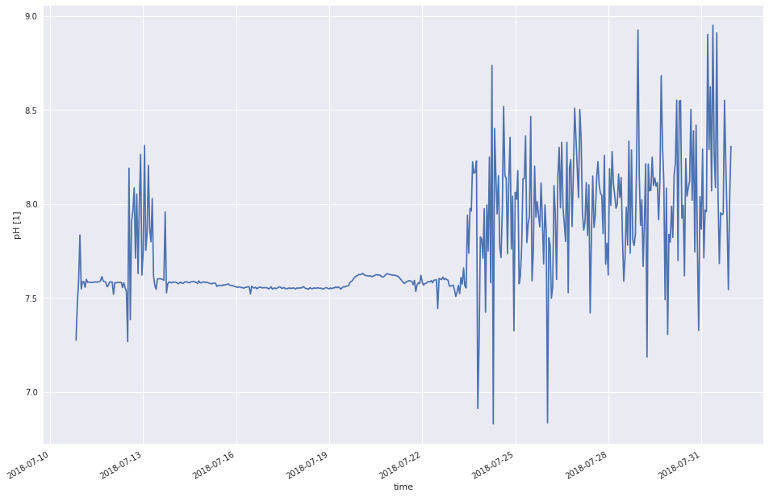

```python
# plot data set 1
fig,(ax)=plt.subplots(figsize=(16,10))
ds1['ph_seawater'].plot(ax=ax)
```

Here we see a brief blip of high variability around 2018-07-13, and then some stable data, then high variability later in the month. It is unlikely that pH is varying that significantly, so we have higher suspicion about the data.

Here we also see that we only have data plotted from the second deployment in this data set. Let's look at why:

```python
# just look at the raw data
ph1=ds1['ph_seawater'].values
ph1
```

```
array([       nan,        nan,        nan, ..., 7.54356863, 8.03185544,
       8.30481436])
```

Looks like we may have nan for all of deployment 4. Let's check that.

```python
deploymentarray=ds1['deployment'].values
deployment4booleanarr=(deploymentarray==4)
phdep4=ph1[deployment4booleanarr]
phdep4
```

[output not shown]

That's all "nan" indeed! Something must be wrong with the data here! There should probably be an annotation about it - CE02SHBP-LJ01D-10-PHSEND103, deployment 4 is all "nan". We'll look at the raw data later and diagnose the issue.

Here's what we get from the online user interface:

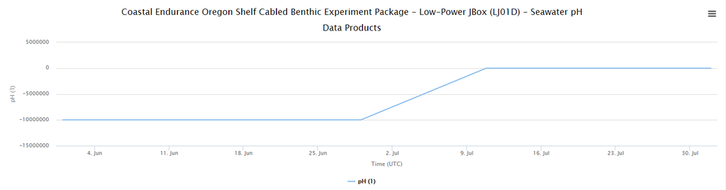

```python
from IPython.display import Image
Image(filename='OOI_GUI_Data_1.PNG',width=900)
```

Looks like the user interface displays nan as -10000000...

Let's look at data set 2 now

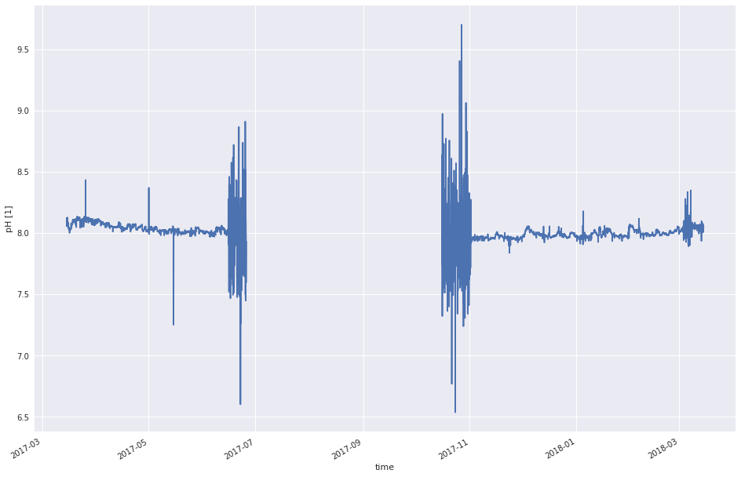

```python
fig,(ax)=plt.subplots(figsize=(16,10))
ds2['phsen_abcdef_ph_seawater'].plot(ax=ax)
site2phdata=ds2['phsen_abcdef_ph_seawater'].values
```

```python
site2phdata
deploymentarray=ds2['deployment'].values
deployment6booleanarr=(deploymentarray==6)
phdep6=site2phdata[deployment6booleanarr]
phdep6
```

```
array([8.22783653, 7.90508167, 8.27701397, ..., 8.14266757, 8.00593856,
       8.27169367])
```

Looks like we have at least the beginning and end of this data set. This may correspond with the highly variable portion of the previous plot. Let's look somewhere at the center of this data set.

```python
site2phdata[4753]
```

```
nan
```

Looks like we have "nan" in the middle.

Let's compare to what we get from the online user interface.

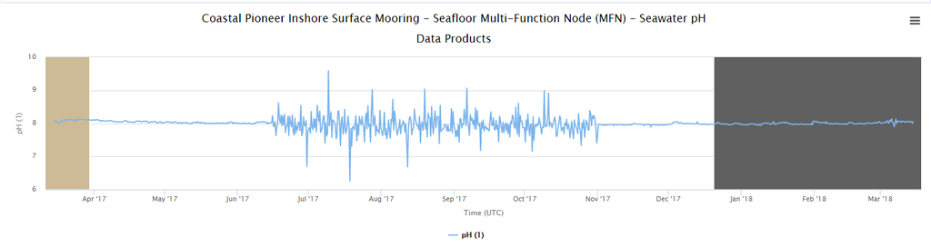

```python
from IPython.display import Image
Image(filename='OOI_GUI_Data_2.PNG',width=900)
```

Here we have data for the middle! Somehow the online interface has more data than we have when we download the data. In theory the data download should give us this data. This is *suspicious* with regard to the data quality. Compared to the high variability in the 2nd deployment of this data set, the first and last deployments look like they might be ok.

The annotations correspond to the annotations we pulled using the API.

### 2. d. Automated QC Test Results

Now lets look at what quality tags we have from the automatic quality checks.

*Usability note:* It would be really helpful to include a way to include the quality flags on the online gui, if possible. Additionally, it would be helpful to have some sort of chart that would allow you to easily match error codes to their specific errors - the number to binary conversion takes a long time to understand and a chart could help visually show you that conversion. I go through the process of parsing those codes here.

```
(736846.0, 736907.0)
```

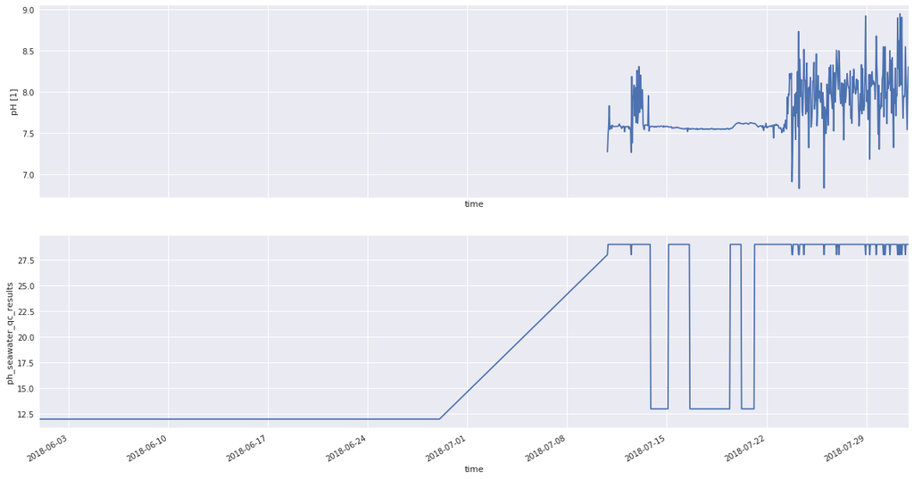

```python
fig, (ax1,ax2) = plt.subplots(2,1, sharex=True, sharey=False, figsize=(20,10))
ds1['ph_seawater'].plot(ax=ax1);
ds1['ph_seawater_qc_results'].plot(ax=ax2);
ax2.set_xlim('2018-06-01','2018-08-01') # Set the time limits to match the dataset
ax1.set_xlim('2018-06-01','2018-08-01') # Set the time limits to match the dataset
```

To interpret the QC data we need to understand the QC codes. To do that we use this binary key: The QC flags for all tests are OR'd together to produce a single value for each data point. So, given a qc_executed value of 29 we can see which tests were run by reversing the process:

QC table

```
Test name              Bit position
                         15 14 13 12 11 10  9  8  7  6  5  4  3  2  1  0
global_range_test         0  0  0  0  0  0  0  0  0  0  0  0  0  0  0  1
dataqc_localrangetest     0  0  0  0  0  0  0  0  0  0  0  0  0  0  1  0
dataqc_spiketest          0  0  0  0  0  0  0  0  0  0  0  0  0  1  0  0
dataqc_polytrendtest      0  0  0  0  0  0  0  0  0  0  0  0  1  0  0  0
dataqc_stuckvaluetest     0  0  0  0  0  0  0  0  0  0  0  1  0  0  0  0
dataqc_gradienttest       0  0  0  0  0  0  0  0  0  0  1  0  0  0  0  0
dataqc_propagateflags     0  0  0  0  0  0  0  0  1  0  0  0  0  0  0  0
```

So if we want to figure out what an error code of 28 means, we use unpack bits to turn 28 into a binary number, then match it up with this chart.

```python
np.unpackbits(np.array(28).astype('uint8'))
```

```
array([0, 0, 0, 1, 1, 1, 0, 0], dtype=uint8)
```

So an error code of 28 means that it didn't pass the global range test or the local range test, but did pass the spike test, the polytrend test, the stuck value test, and didnt pass the gradienttest and the propagate flags test. Not passing a test here only means something if the test was run. To tell if a test was run, we look at ph_seawater_qc_executed

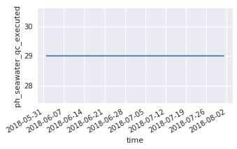

```python
fig,(ax)=plt.subplots(figsize=(5,2.5))
ds1['ph_seawater_qc_executed'].plot(ax=ax)
```

Looks like 29 is the code we need to decode to tell what tests were run. Let's do that:

```python
np.unpackbits(np.array(29).astype('uint8'))
```

```
array([0, 0, 0, 1, 1, 1, 0, 1], dtype=uint8)
```

This means that the global range, spike test, polytrend test, and stuck value test were all performed on this data

The QC codes we see are 12 (for the data set that is all "nan"), 29, 28, and 13. Let's parse those codes:

```python
np.unpackbits(np.array(12).astype('uint8'))
```

```
array([0, 0, 0, 0, 1, 1, 0, 0], dtype=uint8)
```

This didn't pass the stuck value or the global range test.

```python
np.unpackbits(np.array(13).astype('uint8'))
```

```
array([0, 0, 0, 0, 1, 1, 0, 1], dtype=uint8)
```

This didn't pass the stuck values test.

```python
np.unpackbits(np.array(28).astype('uint8'))
```

```
array([0, 0, 0, 1, 1, 1, 0, 0], dtype=uint8)
```

This didn't pass the global range test.

So now we know what automated QC tests this data passed/didn't pass.

We already know that we have "nan" for data for deployment 4. Let's zoom in on deployment 5 to look at the data.

```
(736875.1041666666, 736907.0)
```

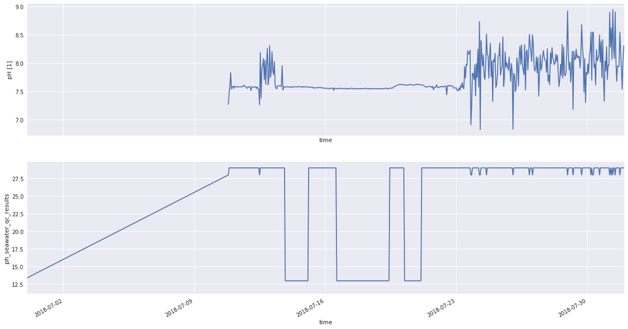

```python
fig, (ax1,ax2) = plt.subplots(2,1, sharex=True, sharey=False, figsize=(20,10))
ds1['ph_seawater'].plot(ax=ax1);
ds1['ph_seawater_qc_results'].plot(ax=ax2);
ax2.set_xlim('2018-06-30 02:30:00','2018-08-01') # Set the time limits to match the dataset
ax1.set_xlim('2018-06-30 02:30:00','2018-08-01') # Set the time limits to match the dataset
```

It looks like we don't really have data for the beginning of this data set. It's unclear why. For the last portion of the data set, we'll look further at the raw data. It would appear that the data with high variability is probably suspicious data. Though the data in mid-deployment did not pass the stuck value test, it might actually be good data. Let's look at the raw data to confirm, but just because it didn't pass the automated stuck value test doesn't necessarily mean that it is bad data.

Let's take a look at the data quality flags on data set 2:

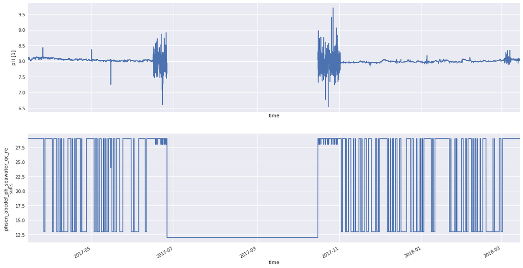

```python
fig, (ax1,ax2) = plt.subplots(2,1, sharex=True, sharey=False, figsize=(20,10))
ds2['phsen_abcdef_ph_seawater'].plot(ax=ax1);
ds2['phsen_abcdef_ph_seawater_qc_results'].plot(ax=ax2);
ax2.set_xlim(beginDate_2,endDate_2) # Set the time limits to match the dataset
ax1.set_xlim(beginDate_2,endDate_2) # Set the time limits to match the dataset
```

Here we have QC codes 29, 28, 13, and 12 again. 29 = passed all tests 28 = failed global range test 13 = failed stuck value test 12 = failed stuck value test and global range test In this case again we might be suspicious about the stuck value test. The other codes make sense.

# 3. Quality Checks on Raw Data Products

Let's see if we can identify any issues in the raw data that might lead us to believe this is either high quality data or spurious measurements. In order to understand the raw data, we need to understand some of how the pH instrument works. I've included a brief explanation of what I ascertained from the data processing code and a few academic papers on the SAMI-pH sensor in the appendix of this report. If this raw data section does not make sense, I hope the instrument walk through in the appendix will be helpful. Please note this is just what I was able to glean from a few papers and documentation during the data workshop - take it with a grain of salt!

### 3. a. Light Measurement Checks

#### Checking the Blank Raw Data

First, let's understand what the raw data from the blank measurements looks like.

```
(736880.0, 736906.0)
```

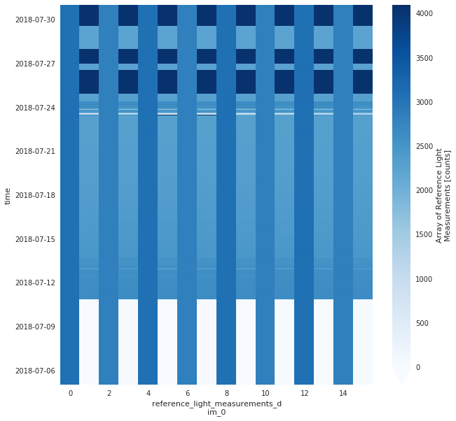

```python
# plot the reference light measurements == blank measurements (NOTE: this notation is misleading! These aren't measurements from the reference detector, they're measurements of blank seawater)
fig,(ax)=plt.subplots(figsize=(10,10))
ds1['reference_light_measurements'].plot(ax=ax,cmap='Blues',vmin=0, vmax=4096);
ax.set_ylim('2018-07-05','2018-07-31') # Set the time limits to match the dataset
```

Unfortunately I was unable to find a better way of displaying this data in our short workshop time period. To "read" this diagram, recall that the instrument feeds in a seawater "blank" with no indicator solution in it. Reading from left to right at one date position (on the y-axis), we see the 16 measurements needed for the blank signal. These alternate between the input light intensity detector and the output light intensity detector, and alternate between the 2 wavelengths of light. The intensity of the blue indicates the intensity of the light. (In this case intensity is measured in terms of analog to digital "counts", but the units wash out in the math as long as the two detectors are the same sensitivity)

Note: It is unclear from the documentation whether these blank measurements are all taken before the pH measurement, or if half of the blank measurements are taken before measuring the sample and half afterward. (the latter would allow us to have more diagnostic information in the case that the indicator was not sufficiently clearing the system). It was also unclear what the order of these measurements were, but we can make an educated guess.

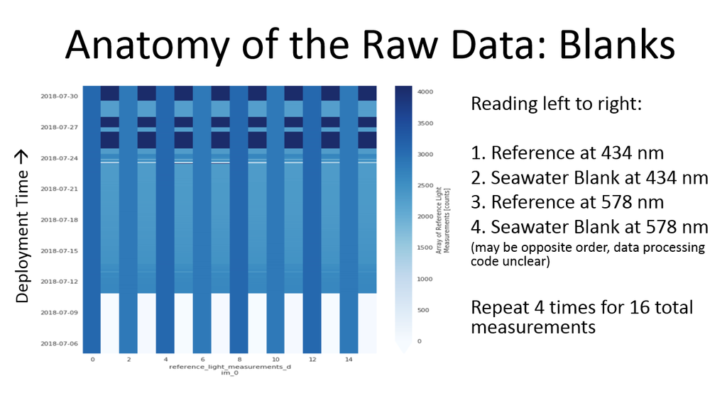

```python
from IPython.display import Image
Image(filename='OOI_blankanatomy.PNG',width=900)
```

Now from understanding a bit of how the instrument works we can identify when things aren't working as expected in the raw blank data. First, in the date range between 2018-07-06 and 2018-07-11 we see almost zero light making it through the optical cell. If no light is making it through the cell, then this data is not measuring the pH, and should be flagged as *bad* data. Towards the middle of the time range we see what appears to be reasonable raw data. The intensity of the output and input light are comparable (perhaps a bit attenuated on the output light). If we look closely we see the intensity of the output light slowly drop over time. This could be a subtle symptom of biofouling. If we look in the date range 2018-07-24 and onwards, we see that the light coming through the output of the system is significantly greater than the input light. Since a 50-50 beam splitter is used, this is physically impossible. Either more light is being generated in the cell (highly unlikely, unless there is some sort of bioluminescense at a wavelength to which the detector is sensitive), or something is going wrong with the detection electronics. This data should also be flagged as *bad* data.

From looking at the raw data we flagged the following areas:

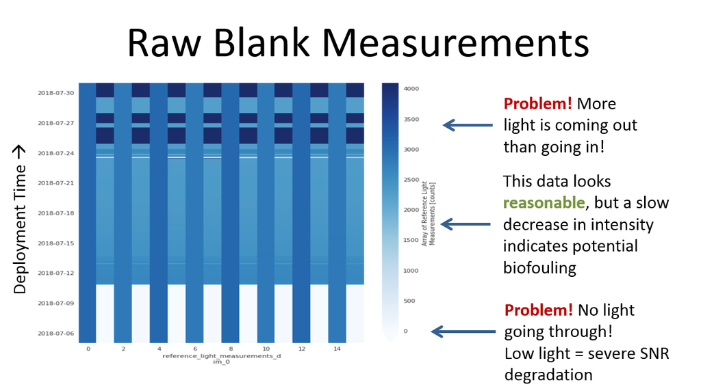

```python
from IPython.display import Image
Image(filename='OOI_flaggedrawdata.PNG',width=900)
```

```
(6.5, 9)
```

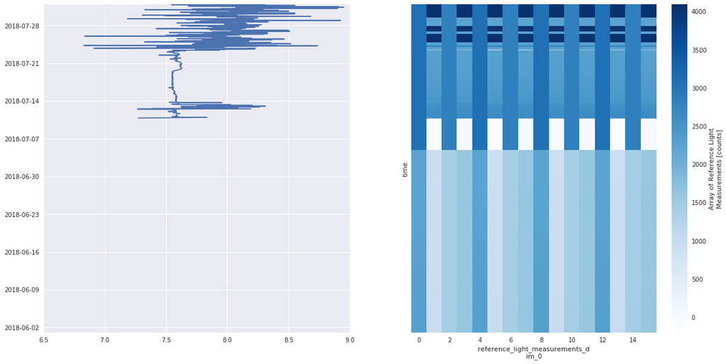

```python
ph1=ds1['ph_seawater'].values
time1=ds1['time'].values
fig,(ax1,ax2)=plt.subplots(1,2, sharex=False, sharey=True, figsize=(20,10))
ds1['reference_light_measurements'].plot(ax=ax2,cmap='Blues',vmin=0, vmax=4096);
#ax2.set_ylim('2018-07-10','2018-07-31') # Set the time limits to match the dataset
scl=ax1.plot(ph1,time1)
ax1.set_xlim(6.5,9)
```

Let's zoom in on the last deployment since we only have "nan" data for the first one:

```
(6.5, 9)
```

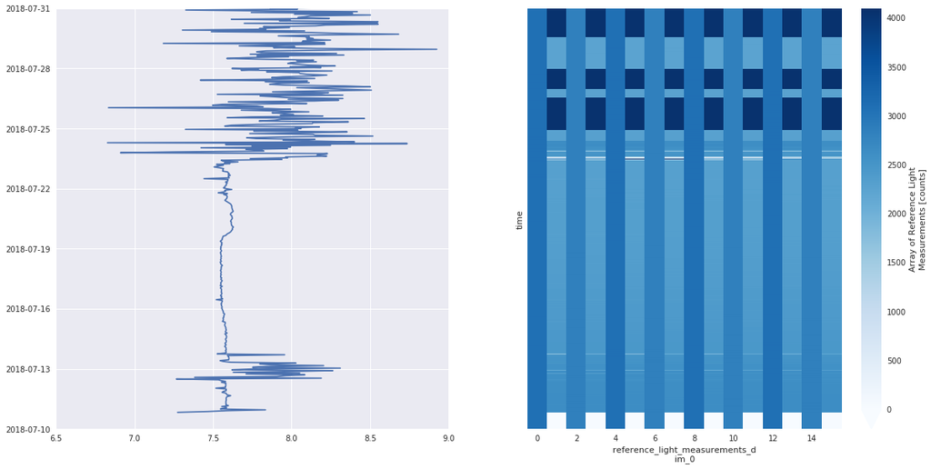

```python
fig,(ax1,ax2)=plt.subplots(1,2, sharex=False, sharey=True, figsize=(20,10))
ds1['reference_light_measurements'].plot(ax=ax2,cmap='Blues',vmin=0, vmax=4096);
ax2.set_ylim('2018-07-10','2018-07-31') # Set the time limits to match the dataset
scl=ax1.plot(ph1,time1)
ax1.set_xlim(6.5,9)
```

Looks like the areas identified as suspect from looking at the raw data corresponds with areas with high variability in pH data.

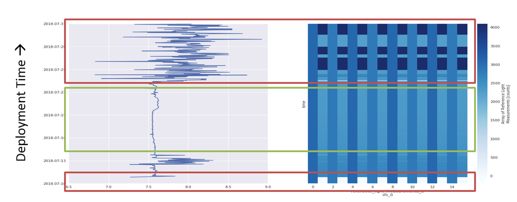

```python
from IPython.display import Image
Image(filename='OOI_rawdata_highvariability_boxes.PNG',width=900)
```

It looks like potentially the section highlighted in green here could be good data. We'll look at the raw data for the sample measurements for that in the next section.

Next, let's look at the raw blank data for data set 2:

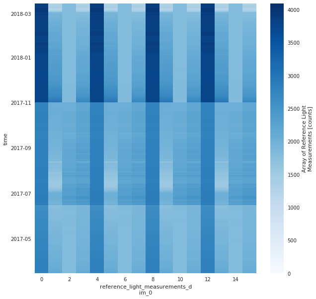

```python
# plot the reference light measurements == blank measurements (NOTE: this notation is misleading! These aren't measurements from the reference detector, they're measurements of blank seawater)
fig,(ax)=plt.subplots(figsize=(10,10))
ds2['reference_light_measurements'].plot(ax=ax,cmap='Blues',vmin=0, vmax=4096);
```

We can fairly easily see the 3 deployment periods here by observing the sharp line between measurements.In the previous set of data it was easier to make an educated guess about the order of the measurements. It was input light intensity for wavelength 1, output light intensity for wavelength 1, input light intensity for wavelength 2, and output light intensity for wavelength 2. Since a 50-50 beam splitter is used, we'd expect for the blank samples that the input and output light intensity measurements are roughly the same, and if there is any turbidity, biofouling, etc then the output intensity measurement should be less than the input measurement. Here we see that the first two measurements match up with the paradigm of input intensity measurement then output intensity measurement. However the next two the first measurement is lower than the subsequent measurement, and consistently so across all 3 deployments. Another clue we can use is we know that the input light intensity shouldn't really vary much, since in theory nothing is changing in that optical path, except for potential misalignment changes with temperature change (the temp doesn't change much there, so that's unlikely) or aging of the electronics. Looking at the most recent deployment it appears that the two most consistent "bars" are the first and second. For the middle deployment it appears that the input intensity measurement was varying more than we've seen with this small selection of data. This is suspicious. For the oldest deployment the data is almost too consitent. If that's real, then that's really good! If everything is *exactly* the same, then it would be good to check that there wasn't a processing or data logging error.

This data is hard to interpret, because it almost appears to be in a different order than the other set of data. Since there wasn't a way to figure out exactly what order these are in, it is hard to diagnose. Since these two data sets have very different variable names, data outputs, etc, it is possible that the order of these measurements is different.

Let's plot the raw data next to the pH data for this data set:

```
(6.5, 9)
```

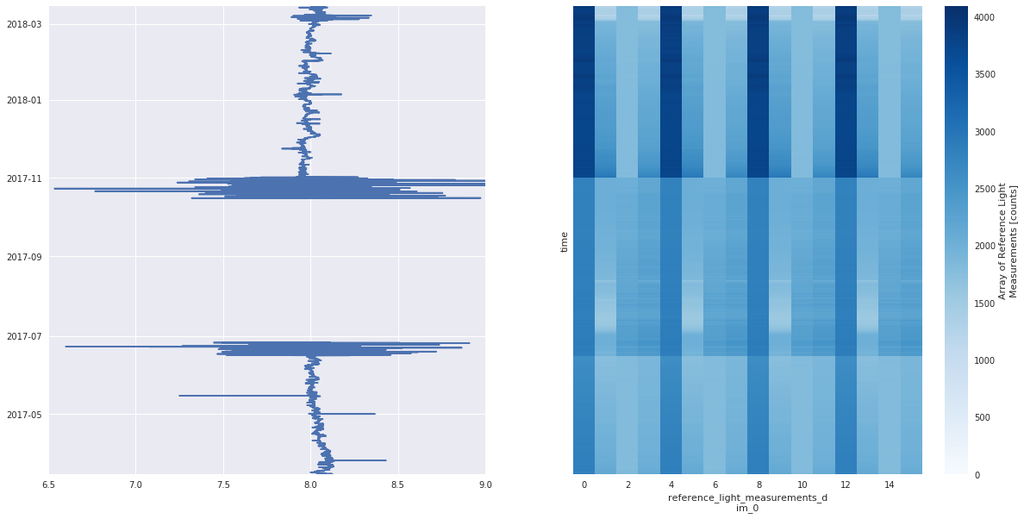

```python
ph2=ds2['phsen_abcdef_ph_seawater'].values
time2=ds2['time'].values
fig,(ax1,ax2)=plt.subplots(1,2, sharex=False, sharey=True, figsize=(20,10))
ds2['reference_light_measurements'].plot(ax=ax2,cmap='Blues',vmin=0, vmax=4096);
scl=ax1.plot(ph2,time2)
ax1.set_xlim(6.5,9)
```

We don't get as great of a match up here as we did with the previous data set.

#### Checking the Measurement Raw Data

Now let's look at the pH measurement data. I've displayed this in the same manner as the blank data. Deployment time is on the y axis, measurement number (or instrument measurement time) is on the x axis, and the shade of blue indicates the intensity of the light measured. It alternates input light intensity measurements with output light intensity measurements. Again the documentation is unclear on the exact order (which wavelength is first or second) but we can make an educated guess with this data.

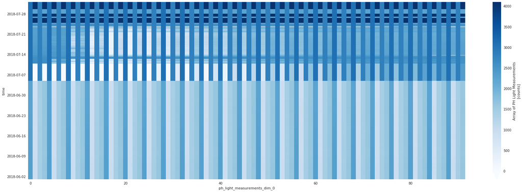

```python
fig,(ax)=plt.subplots(figsize=(30,10))
ds1['ph_light_measurements'].plot(ax=ax,cmap='Blues',vmin=0, vmax=4096);
# ax.set_ylim('2018-07-05','2018-07-31') # Set the time limits to match the dataset
```

Here we can identify several features indicating whether or not the instrument is working as it should. This signal should vary with time as the "pulse" of dye moves through the system. Looking at the first deployment, we don't see this pulse moving through. The data processing code returned "nan" for all of this data, likely because it couldn't fit the pulse moving through. The extraordinary consistency of the measurements over time is also suspicious. We've already marked this data as suspicious, so let's move onto the second deployment of this data set.

Zooming in on the second deployment:

```
(736876.0, 736906.0)
```

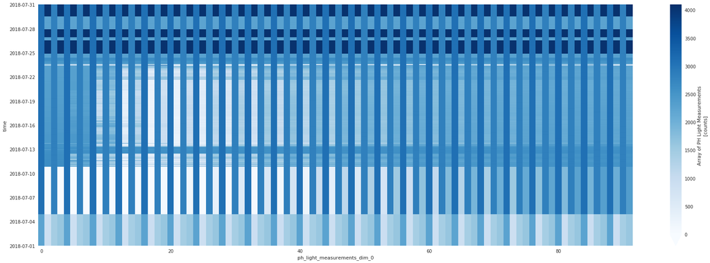

```python
fig,(ax)=plt.subplots(figsize=(30,10))
ds1['ph_light_measurements'].plot(ax=ax,cmap='Blues',vmin=0, vmax=4096);
ax.set_ylim('2018-07-01','2018-07-31') # Set the time limits to match the dataset
```

Just like we saw in the blank data for data set 1, the output detector in latter portion of the deployment appears to have saturated. There should not be more light coming out of the system than is going in. (at least, not this significantly more) This is not physical and indicates that we shouldn't trust this data.

Looking towards the middle of the deployment we see something that looks like good data! We can identify the "pulse" of dye moving through the system.

At the beginning of the deployment it appears as if the dye "pulse" might have occured too soon. This may be an issue with the pump, and will likely show up in the data as high variability because of the curve fitting process.

Here is a sketch identifying the "pulse" of indicator visually:

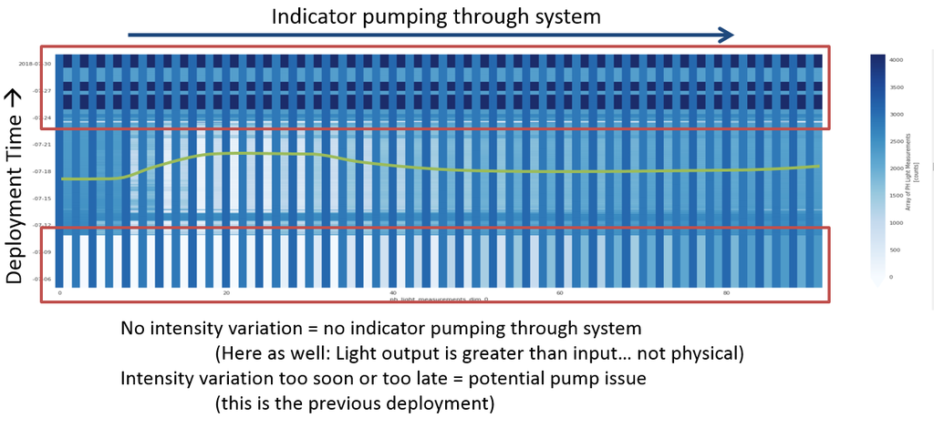

```python
from IPython.display import Image
Image(filename='OOI_indicatorpumping.PNG',width=900)
```

Let's look at the raw data and the pH data side by side.

```
(6.5, 9)
```

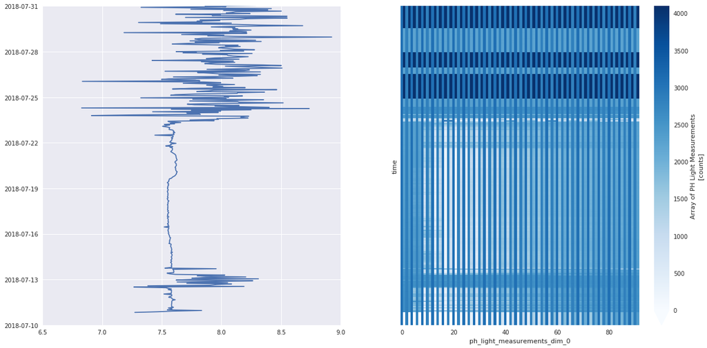

```python
fig,(ax1,ax2)=plt.subplots(1,2, sharex=False, sharey=True, figsize=(20,10))
ds1['ph_light_measurements'].plot(ax=ax2,cmap='Blues',vmin=0, vmax=4096);
ax2.set_ylim('2018-07-10','2018-07-31') # Set the time limits to match the dataset
scl=ax1.plot(ph1,time1)
ax1.set_xlim(6.5,9)
```

That center section passed inspection on both the blank and the sample measurements. Let's look closer at that:

```
(6.5, 9)
```

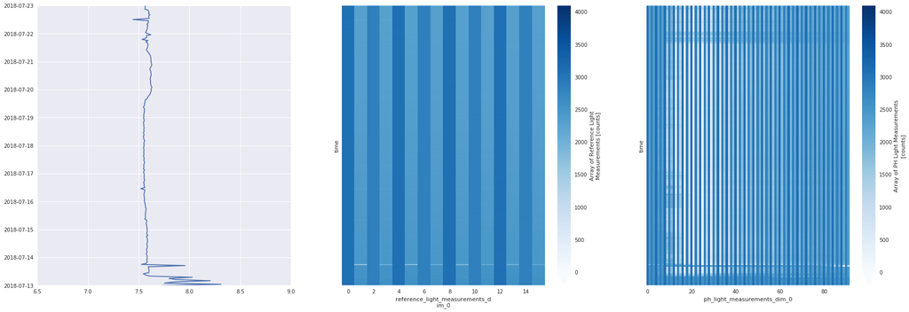

```python
fig,(ax1,ax2,ax3)=plt.subplots(1,3, sharex=False, sharey=True, figsize=(30,10))
ds1['reference_light_measurements'].plot(ax=ax2,cmap='Blues',vmin=0, vmax=4096);
ds1['ph_light_measurements'].plot(ax=ax3,cmap='Blues',vmin=0, vmax=4096);
ax2.set_ylim('2018-07-13','2018-07-23') # Set the time limits to match the dataset
scl=ax1.plot(ph1,time1)
ax1.set_xlim(6.5,9)
```

This looks pretty good. Let's rescale that pH axis so we can see the small scale variablility.

```
(7.5, 7.65)
```

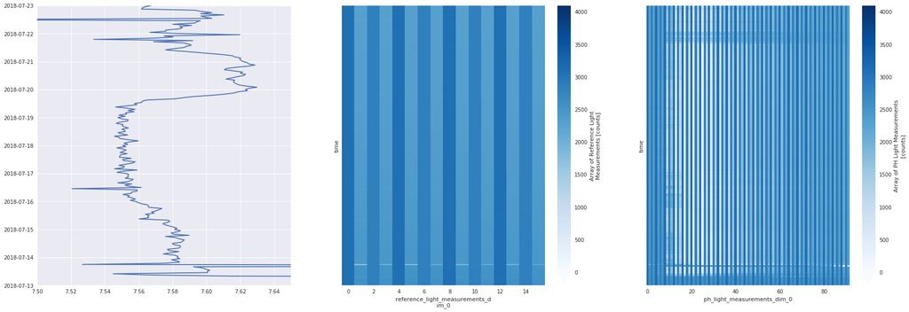

```python
fig,(ax1,ax2,ax3)=plt.subplots(1,3, sharex=False, sharey=True, figsize=(30,10))
ds1['reference_light_measurements'].plot(ax=ax2,cmap='Blues',vmin=0, vmax=4096);
ds1['ph_light_measurements'].plot(ax=ax3,cmap='Blues',vmin=0, vmax=4096);
ax2.set_ylim('2018-07-13','2018-07-23') # Set the time limits to match the dataset
scl=ax1.plot(ph1,time1)
ax1.set_xlim(7.5,7.65)
```

This data looks pretty good! It is worth noting here that this data failed the stuck value test.

Let's look at the raw data from the second data set:

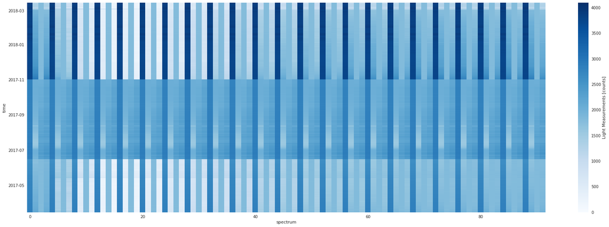

```python
fig,(ax)=plt.subplots(figsize=(30,10))
ds2['light_measurements'].plot(ax=ax,cmap='Blues',vmin=0, vmax=4096);
```

It looks like in the most recent data set that we can see the "pulse" of indicator moving through the system. A pulse is not visually identifiable in the middle data set. The pulse is identifiable in the earliest data set.

```
(6.5, 9)
```

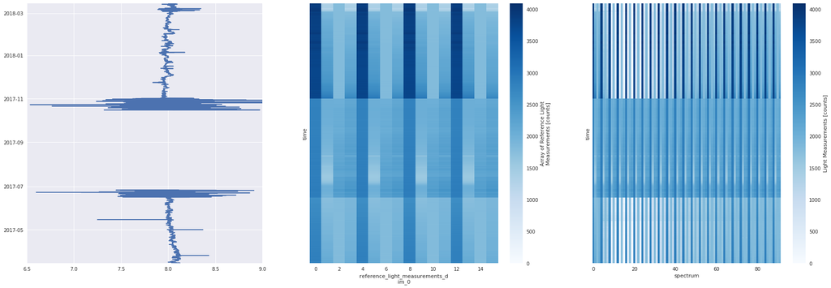

```python
fig,(ax1,ax2,ax3)=plt.subplots(1,3, sharex=False, sharey=True, figsize=(30,10))
ds2['reference_light_measurements'].plot(ax=ax2,cmap='Blues',vmin=0, vmax=4096);
ds2['light_measurements'].plot(ax=ax3,cmap='Blues',vmin=0, vmax=4096);
# ax2.set_ylim('2018-07-13','2018-07-23') # Set the time limits to match the dataset
scl=ax1.plot(ph2,time2)
ax1.set_xlim(6.5,9)
```

Other than the issue of not being able to identify the order of the measurements via educated guess, the sample measurements look decent. There is higher variablility in the measurements here, potentially due to the lower light making it through the optical cell. This might be chance, but since it occured on all 3 instruments deployed here it may be due to environmental conditions, perhaps highly turbid water.

### 3. b. Additional Instrument Checks

While it is outside the scope of this report, it would also be prudent to check the other sets of raw data from the sensor. For example, the instrument battery voltage should have some operating range, and if it is outside of that then the data should be flagged as suspicious. Similarly, if the temperature sensor reads outside an expected range, it should be flagged as suspicious. In these data sets the temperature data looked ok, and the battery data looked suspicious in places:

Looking at the temperature data:

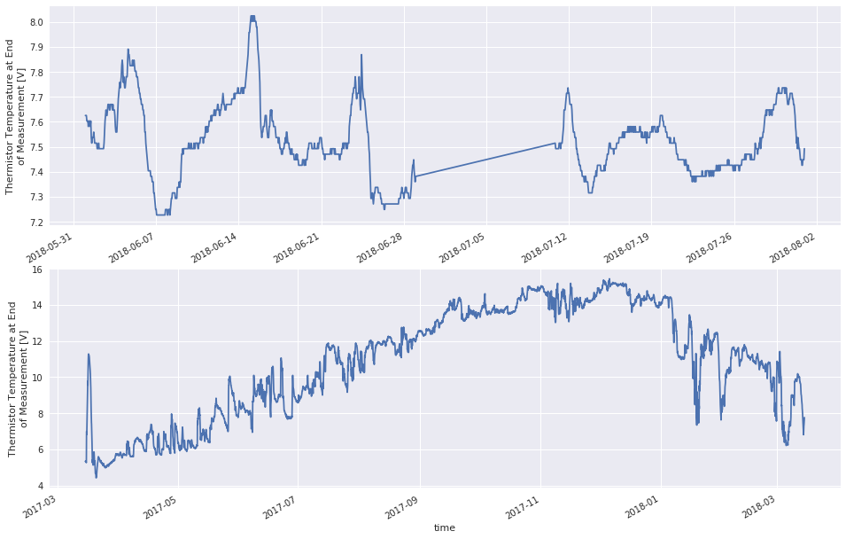

```python
fig, (ax1,ax2) = plt.subplots(2,1, sharex=False, sharey=False, figsize=(16,10))
ds1['phsen_thermistor_temperature'].plot(ax=ax1);
ds2['phsen_thermistor_temperature'].plot(ax=ax2);
```

This looks good for both data sets!

Looking at the battery data:

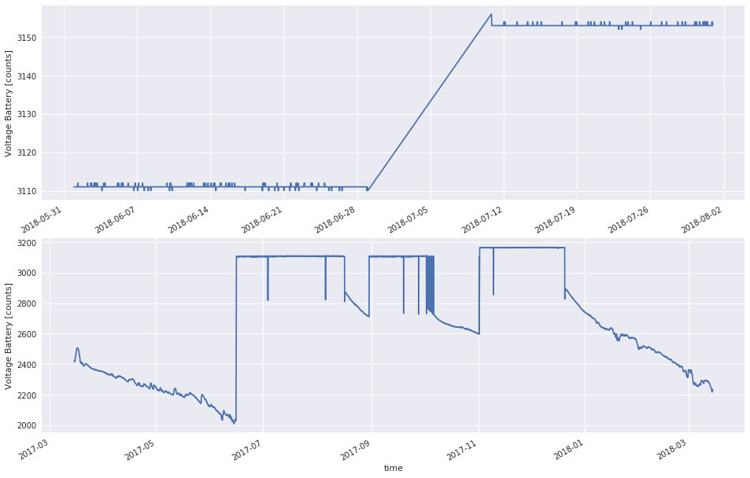

```python
fig, (ax1,ax2) = plt.subplots(2,1, sharex=False, sharey=False, figsize=(16,10))
ds1['voltage_battery'].plot(ax=ax1);
ds2['voltage_battery'].plot(ax=ax2);
```

Unfortunately I was unable to find information on how to convert counts to voltage, and without that information it is hard to make a judgement on this data. It depends on the type of battery (also not available information) but at first look it would appear that either different battery types are being used on different deployments, or the battery performance is different on different deployments.

Working with the available information, the battery information for data set 1 looks good, the battery information for data set 2 looks like it needs another look once we know what kind of battery was used, especially the set from 1017-07 through 2018-01.

I'd expect there's an acceptable operation range that could be monitored for the battery.

### 3. c. Additional Data Quality Observations

It is challenging to tell what order the raw data is presented in. There are some hints in the data processing code, but I was only able to tell the order by figuring out how the instrument worked first, and then guessing the most likely option. Clearer comments on the data processing script would be helpful.

It is unclear what order the data is collected from the instrument. For example, I cannot tell if a seawater blank is collected, then a sample, then a seawater blank, or if all blanks are taken first and then the sample is measured. This affects how one might interpret the data because a blank after the sample with less light throughput than the blank before the sample might suggest that the pump is not fully clearing all of the pH indicator.

# 4. Data Quality Improvements: Suggestions

**Operations:** From an operational perspective, it would be good to check the functionality of the instrument before deployment, and to document that check. I'm sure some checking is done before instruments are deployed, but in the case of deployment 4 of data set 1 it was clear from the raw data that the instrument really wasn't working from the start. Potentially this was because the instrument couldn't pump samples due to a bubble captured on deployment. (A deployment issue that has since been rectified.)

**Instrument design suggestions:** Recognizing that these adjustments would fall on the vendor, some suggestions that might improve the performance of the instrument include: Including a UV light (integrated into the onboard optical setup) to use for biofouling prevention. Using a more powerful pump (to avoid the bubble purge issue at deployment). Averaging measurements, collecting more light measurements per measurement cycle and averaging repeated light measurements (to improve SNR, assumes noise characteristics are gaussian and white), using an analog to digital converter with higher resolution (especially at low light levels this is hurting the system).

# Appendix: Instrument Operation

To understand the basics of how the instrument works I read the following papers:

DeGrandpre et al. Considerations for the measurement of spectrophotometric pH for ocean acidification and other studies. Limnology and Oceanography Methods 2014. https://doi.org/10.4319/lom.2014.12.830

Lai et al. Autonomous Optofluidic Chemical Analyzers for Marine Applications: Insights from the Submersible Autonomous Moored Instruments (SAMI) for pH and pCO2. Fronteirs in Marine Science 2018. https://www.frontiersin.org/articles/10.3389/fmars.2017.00438/full

I also referenced the pH sensor [DPS](https://oceanobservatories.org/wp-content/uploads/2015/10/1341-00510_Data_Product_Spec_PHWATER_OOI.pdf) and the [pH sensor processing code.](https://github.com/oceanobservatories/ion-functions/blob/master/ion_functions/data/ph_functions.py)

The explanation provided here was drawn largely from my OOI workshop presentation.

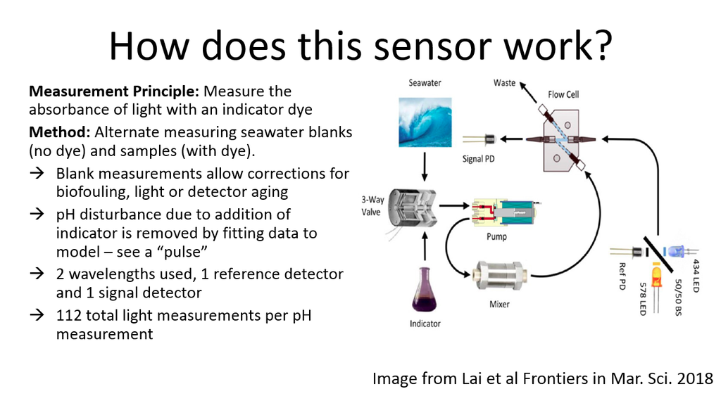

```python
from IPython.display import Image
Image(filename='OOI_howphsensorworks_1.PNG',width=900)
```

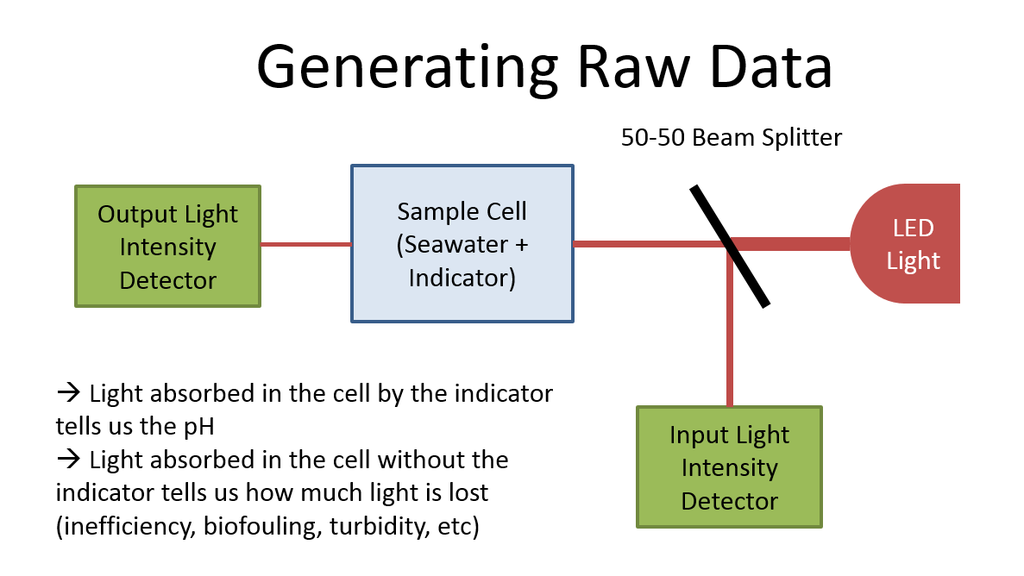

```python
from IPython.display import Image
Image(filename='OOI_blockdiag.PNG',width=900)
```

This simplified diagram shows how light propagates through the system. The instrument generates light at 434nm and 578 nm using two LED lights and narrow band optical filters. The intensity of the LED light is monitored by the input light intensity detector. The intensity of the light passing through the sample cell is monitored by the output light intensity.

In order to make a measurement, the instrument does two things: measure a seawater blank and measure a sample with indicator mixed in. The documentation was unclear as to the order of operations, so I'll present it in the order that might make the raw data make the most sense:

First, the instrument takes a blank sample. To do this, it pumps clean seawater into the sample cell. Then it measures the amount of light going through the sample cell, while simultaneously measuring the input light intensity. This measurement gives you the attenuation of the optical setup (from a number of things, like biofouling, optical inefficiencies, turbidity, misalignment, etc). It's quite clever, because this allows the instrument to essentially calibrate the optical setup *in situ* and before/after every measurement. This is one of the features that allows the instrument to keep its impressive pH measurement specifications.

Then the instrument takes a sample. It does this by mixing the indicator with the seawater sample and pumping that through the optical cell. As seawater gets pumped through the cell, a "pulse" or "bolster" of dye passes past the optics. In the raw data we see this as first essentially a blank measurement, then higher and higher attenuation (drop in output intensity without corresponding drop in input intensity) as the pulse of dye moves by, and then a return to what is essentially a blank measurement. The data processing code fits a curve to this pulse and allows the pH disturbance induced by the addition of the dye to be backed out of the equation, giving you the pH of the seawater (as if you hadn't disturbed the pH by adding the indicator). Pretty clever too!

The measurements of the attenuation through blank seawater and the attenuation of the indicator-mixed seawater at two wavelengths are used in conjunction with temperature and salinity measurements to calculate the pH.

**From understanding the sensing methodology we can identify some potential quality checks on the data:**

1. If the input light intensity drops, then we know there must be a problem with the LED or the input light intensity detector, or another electrical problem. Biofouling should not affect this measurement. A potential data quality flag (that would almost always pass) would be to check for any significant deviation in the input light intensity.
2. If during a blank sample measurement the input light intensity vs the output light intensity is significantly different, then we know there is something wrong with that "leg" of the optical system. This could be a potential quality flag that would catch most of the times when the pH data was highly variable, as we saw with the raw data. Most likely this drop in light throughput would be biofouling of the optical windows where the light passes through the seawater. Some other potential causes include the indicator not flushing through the system. If we see a steady increase in the attenuation of the light through the cell (i.e. drop in blank measurement intensity without corresponding drop in input intensity), then we know something is slowly failing in the instrument. This could serve as an "early warning" sign that the instrument might need repair and that the data might not be as high quality. Thinking strictly of the noise properties, the signal to noise ration significantly worsens as less and less light makes it through the "blank" optical system. If one were particularly invested, propagation of uncertainty could be used to back out this increased variability in the measurements. When we look at the data we see this in practice - when the blank signal is low or almost zero, we see the variability of the pH measurements increase significantly. These jumps are not because the pH is actually changing that much! One potential fix, assuming the noise is Gaussian and white, would be to average multiple pH measurements. You'd lose time resolution, but if the noise is Gaussian and white, your measurements should improve by the square root of n as you take more measurements. In order for that to be valid you also have to assume that the pH isn't changing in time over the time that you average, so that assumption would need to be carefully justified or acknowledged. Another option would be to increase the sampling frequency of the pH sensor and averaging those measurements, but that would drain battery and indicator faster.
3. If during a sample measurement the characteristic "pulse" is not observed, then there is something wrong with the sampling mechanism. The data processing code fits this "pulse" and generally returns "nan" if it cannot be fit (ex: deployment 4 of data set 1) However we can also observe other impacts when we don't get "nan" - if the pulse comes too soon or too late, that might indicate issues with the pump pumping.